# Intro to Parameter Estimation

Arjun Panda, Erin Boon, David Noonan

## Intro

This was a take-home quiz in our Statistical Theory course, demonstrating maximum likelihood estimation, bootstrapping, and Baysian parameter estimation in three short questions. I haven’t been able to find the original problem set, but the questions can be more or less inferred from their solutions below.

### Question 1

#### a.

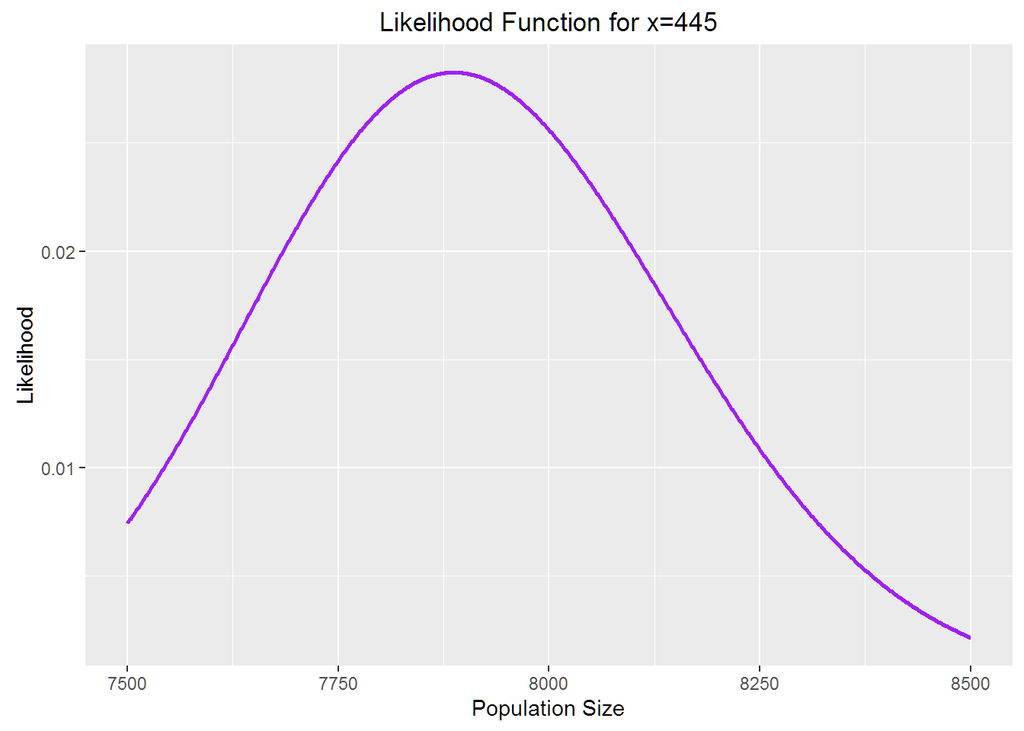

```r
tau <- 7500:8500
r <- 3900
k <- 900
x <- 445
like <- dhyper(x,r,tau-r,k)
likelihood <- data.frame(tau, like, row.names = NULL)


library("ggplot2", lib.loc="~/R/win-library/3.2")

ggplot(likelihood, aes(x = likelihood$tau, y= likelihood$like)) +
  geom_line(color = "purple", size = 1) +
  labs(x = "Population Size", y = "Likelihood", title = "Likelihood Function for x=445")
```

The plot of the maximum likelihood function for tau shows that the estimation of the population size (tau) is maximized at roughly 7,888 people.

### Question 2

We begin by evaluating a 95 percent confidence interval for the mean change in blood pressure using both parametric and non-parametric (bootstrap) methods.

#### a.

```r
reduction <- c(8.9,13.1,12.8,9.4,5.4,-4.2,-2.6,7.0,9.8,-1.9,-1.7,8.4)
n <- length(reduction)
rm <- mean(reduction)
rsd <- sd(reduction)
error <- qt(0.975, df = n-1)*rsd/sqrt(n)
left <- rm - error
right <- rm + error
ci <- c(left, right)
print(ci)
```

```
## [1] 1.380022 9.353311
```

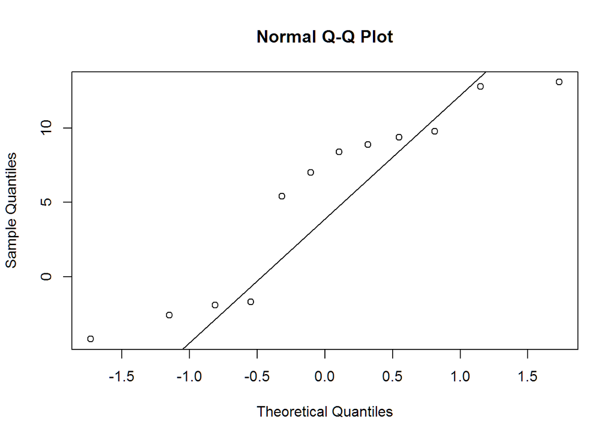

```r
qqnorm(reduction)
qqline(reduction)
```

```r
shapiro.test(reduction)
```

```
##
##  Shapiro-Wilk normality test
##
## data:  reduction
## W = 0.87496, p-value = 0.07556
```

Our results indicate that at an alpha level of 0.05 we can assume normality, but barely. We continue to the non-parametric bootstrapping method of constructing a 95 percent confidence interval for the mean reduction in blood pressure.

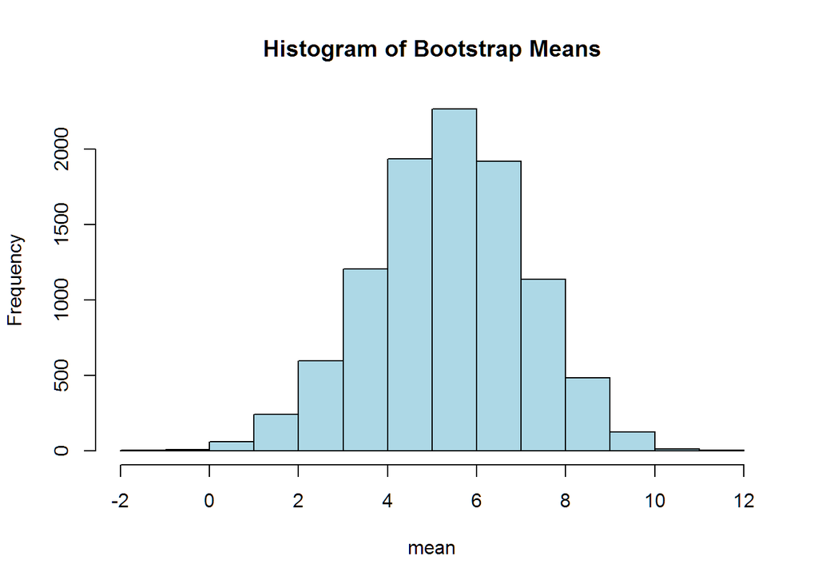

```r
n <- length(reduction)
b <- 10000
bss <- sample(reduction, b*n, replace=T)
bssMatrix <- matrix(bss,nrow=b)
bsm <- rowMeans(bssMatrix)
hist(bsm, col="light blue", main="Histogram of Bootstrap Means", xlab="mean")
```

```r
bsci <- quantile(bsm,c(0.025,0.975))
print(bsci)
```

```
##     2.5%    97.5%
## 1.816667 8.641667
```

#### b.

First, the parametric one-sided t-test:

```r
reduction <- c(8.9,13.1,12.8,9.4,5.4,-4.2,-2.6,7.0,9.8,-1.9,-1.7,8.4)
t.test(reduction, mu=0, alternative = "less")
```

```
##
##  One Sample t-test
##
## data:  reduction
## t = 2.9629, df = 11, p-value = 0.9935
## alternative hypothesis: true mean is less than 0
## 95 percent confidence interval:
##      -Inf 8.619553
## sample estimates:
## mean of x
##  5.366667
```

Now, using our bootstrap samples to establish non-parametric t* values:

```r
rsd=sd(reduction)
bssd=apply(bssMatrix,1,sd)
bst=(bsm-rm)/(bssd/sqrt(n))

tActual = (rm-0)/(rsd/sqrt(n))
pValue = mean(bst < tActual)
print(pValue)
```

```
## [1] 0.9861
```

### Question 3

For this question we use Baysian estimation methods to find the probablity of getting a head in a coin toss (modeled by a Bernoulli trial). From the provided prior data set, we estimated the likelihood distribution. We decided to use a conjugate prior beta distribution for ptheta with parameters a = 3 and b = 10, which results in a convenient posterior probability modeled by the beta distribution as well. Plotted below are the prior, likelihood, and posterior probabilities against theta values.

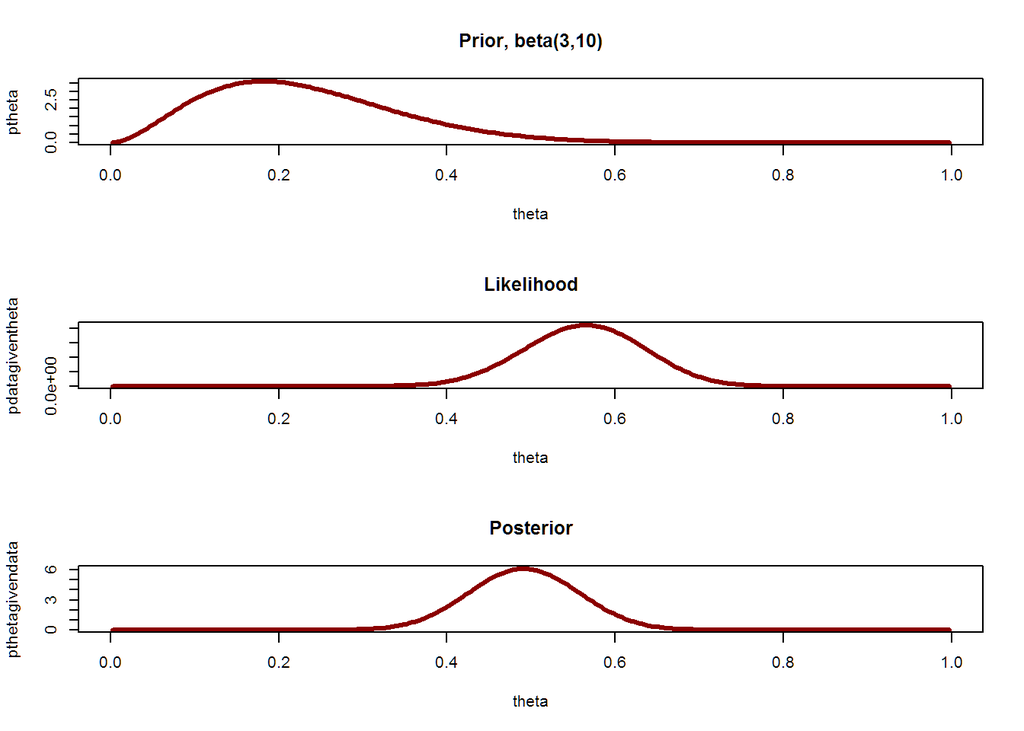

```r
binwidth <- 0.005
theta <- seq(from = binwidth/2, to = 1-(binwidth/2), by = binwidth)
a = 3
b = 10

ptheta <- dbeta(theta, a, b)
coin_toss <- c(1, 1, 1, 1, 1, 1, 1, 1, 1, 1, 1, 1, 1, 1, 1, 1, 1, 1, 1, 1, 1, 1, 1, 1,
               1, 1, 0, 0, 0, 0, 0, 0, 0, 0, 0, 0, 0, 0, 0, 0, 0, 0, 0, 0, 0, 0)
y <- sum(coin_toss == 1)
N <- length(coin_toss)

pdatagiventheta <- theta^y*(1-theta)^(N-y)
pthetagivendata <- dbeta(theta, a+y, N+b-y)

layout(matrix(c(1,2,3), nrow = 3, ncol = 1, byrow = FALSE) )
plot(theta, ptheta, type="l", lwd=3, main="Prior, beta(3,10)", col="darkred" )
plot(theta, pdatagiventheta, type="l", lwd=3, main="Likelihood", col="darkred")
plot(theta, pthetagivendata, type="l", lwd=3, main="Posterior", col="darkred")
```

The posterior distribution is the probability of theta given data. That is, the probability of getting heads considering the prior probabilities of theta (ptheta) as well as the likelihood given our data (pdatagiventheta). The most probable estimator for theta can be evaluated from this.

```r
theta[which(pthetagivendata == max(pthetagivendata))]
```

```
## [1] 0.4925
```

Furthermore, we can evaluate the 95 percent confidence interval for the probability of getting a head from its posterior distribution.

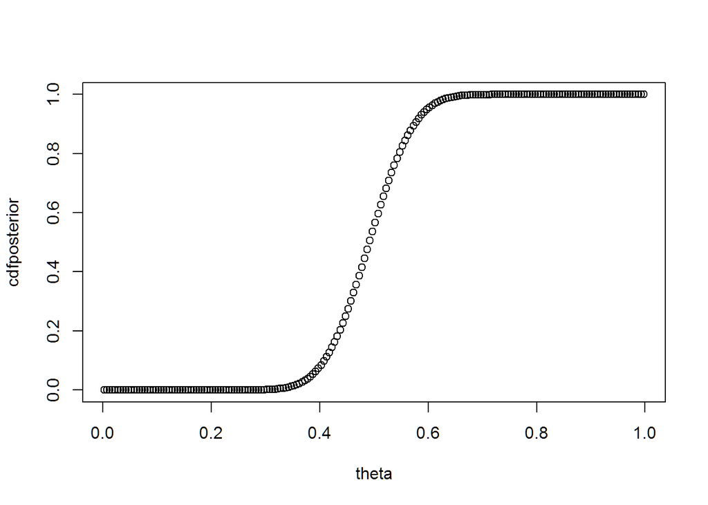

```r
cdfposterior <- pbeta(theta, a+y, N+b-y)
plot(theta, cdfposterior)
```

```r
theta[which.min(abs(cdfposterior - 0.025)) ]
```

```
## [1] 0.3675
```

```r
theta[which.min(abs(cdfposterior - 0.975))]
```

```
## [1] 0.6175
```

Here you see the cdf of the posterior function, which is plotted against theta. Then we found the .025 and .975 quantiles from this data. In conclusion, the posterior distribution tells us that the most likely value for theta is 0.4925, with a 95 confidence interval from 0.3675 to 0.6175. We can clearly see that the information from the prior distribution was used to adjust the liklihood distribution to create the “better informed” posterior distribution, which shifts lower as an adjustment.